# Interpretations

2024-04-10

## Load Packages

The tidyverse is loaded in for you in the code chunk below. The visualization package, ggplot2, and the data manipulation package, dplyr, are part of the “larger” tidyverse.

```r
library(tidyverse)
```

The modelr package is loaded in for you in the code chunk below. You may use functions from modelr to calculate performance metrics for your models.

```r
library(modelr)
```

The caret package to manage all aspects of data splitting, training, and evaluating the models.

```r
library(caret)
```

## Import Data

```r
# Importing training data
train_data_path <- 'paint_project_train_data.csv'
df_train<- readr::read_csv(train_data_path, col_names = TRUE)
# Importing training data
holdout_data_path <- 'paint_project_holdout_data.csv'
df_holdout<- readr::read_csv(holdout_data_path, col_names = TRUE)
df_train %>% glimpse()
```

```
## Rows: 835
## Columns: 8
## $ R          <dbl> 172, 26, 172, 28, 170, 175, 90, 194, 171, 122, 0, 88, 144, …
## $ G          <dbl> 58, 88, 94, 87, 66, 89, 78, 106, 68, 151, 121, 140, 82, 163…
## $ B          <dbl> 62, 151, 58, 152, 58, 65, 136, 53, 107, 59, 88, 58, 132, 50…
## $ Lightness  <chr> "dark", "dark", "dark", "dark", "dark", "dark", "dark", "da…
## $ Saturation <chr> "bright", "bright", "bright", "bright", "bright", "bright",…
## $ Hue        <dbl> 4, 31, 8, 32, 5, 6, 34, 10, 1, 21, 24, 22, 36, 16, 26, 12, …
## $ response   <dbl> 12, 10, 16, 10, 11, 16, 10, 19, 14, 25, 14, 19, 14, 38, 15,…
## $ outcome    <dbl> 1, 1, 1, 0, 0, 0, 0, 0, 0, 0, 0, 0, 0, 0, 0, 0, 0, 0, 1, 1,…
```

## Part iv: Interpretation – ivA) Input Importance.

**Best Regression Model**

```r
logit <- function(p) {
  log(p / (1 - p))
}

df_train$logit_response <- logit((df_train$response - 0) / (100 - 0))
```

1. Interaction terms between the polynomial-transformed continuous variables and the categorical variables

```r
fit_lm9 <- lm(logit_response ~ (poly(R, 2) + poly(G, 2) + poly(B, 2) + Hue) * (Lightness + Saturation), data = df_train)
```

**Best Classification Model**

1.Interaction terms between the polynomial-transformed continuous variables themselves

```r
mod10 <-  glm(outcome ~ poly(R, 2) * poly(G, 2) + poly(R, 2) * poly(B, 2) + poly(R, 2) * poly(Hue, 2) + poly(G, 2) * poly(B, 2) + poly(G, 2) * poly(Hue, 2) + poly(B, 2) * poly(Hue, 2), family = binomial, data = df_train)
```

**Important variables associated with your best performing models**

```r
summary_fit_lm9 <- summary(fit_lm9)
print(summary_fit_lm9)
```

```
##
## Call:
## lm(formula = logit_response ~ (poly(R, 2) + poly(G, 2) + poly(B,
##     2) + Hue) * (Lightness + Saturation), data = df_train)
##
## Residuals:
##       Min        1Q    Median        3Q       Max
## -0.236808 -0.021681 -0.000584  0.020046  0.213288
##
## Coefficients:
##                                  Estimate Std. Error t value Pr(>|t|)
## (Intercept)                    -1.157e-01  6.753e-02  -1.713 0.087173 .
## poly(R, 2)1                     7.690e+00  3.383e-01  22.730  < 2e-16 ***
## poly(R, 2)2                     9.315e-01  1.763e-01   5.282 1.69e-07 ***
## poly(G, 2)1                     2.149e+01  5.829e-01  36.872  < 2e-16 ***
## poly(G, 2)2                     3.711e-01  2.666e-01   1.392 0.164353
## poly(B, 2)1                     1.370e+00  1.440e+00   0.951 0.341733
## poly(B, 2)2                    -1.293e+00  5.138e-01  -2.517 0.012044 *
## Hue                            -5.555e-03  9.673e-04  -5.743 1.37e-08 ***
## Lightnessdeep                  -1.278e-02  6.426e-02  -0.199 0.842466
## Lightnesslight                  7.142e-01  1.508e-01   4.737 2.61e-06 ***
## Lightnessmidtone                1.567e-01  6.910e-02   2.268 0.023606 *
## Lightnesspale                   1.779e+00  3.115e-01   5.712 1.62e-08 ***
## Lightnesssaturated              7.525e-02  6.590e-02   1.142 0.253917
## Lightnesssoft                   3.831e-01  8.204e-02   4.670 3.59e-06 ***
## Saturationgray                 -1.434e-02  2.010e-02  -0.713 0.475813
## Saturationmuted                 2.198e-03  1.633e-02   0.135 0.892989
## Saturationneutral              -6.828e-02  1.677e-02  -4.071 5.19e-05 ***
## Saturationpure                 -2.001e-02  1.714e-02  -1.168 0.243324
## Saturationshaded               -1.746e-02  1.600e-02  -1.091 0.275436
## Saturationsubdued              -3.013e-02  1.718e-02  -1.753 0.079947 .
## poly(R, 2)1:Lightnessdeep      -1.371e-01  3.161e-01  -0.434 0.664673
## poly(R, 2)2:Lightnessdeep       3.390e-01  1.776e-01   1.909 0.056687 .
## poly(R, 2)1:Lightnesslight      2.720e-01  3.743e+00   0.073 0.942087
## poly(R, 2)2:Lightnesslight      7.862e-01  1.856e+00   0.424 0.671912
## poly(R, 2)1:Lightnessmidtone   -2.208e+00  5.018e-01  -4.400 1.24e-05 ***
## poly(R, 2)2:Lightnessmidtone    1.347e+00  3.744e-01   3.598 0.000343 ***
## poly(R, 2)1:Lightnesspale      -1.647e+01  1.023e+01  -1.610 0.107823
## poly(R, 2)2:Lightnesspale       9.158e+00  4.442e+00   2.062 0.039606 *
## poly(R, 2)1:Lightnesssaturated -1.121e+00  3.390e-01  -3.308 0.000987 ***
```

[output cut: 66 more lines]

```
## Hue:Lightnesspale               5.425e-03  9.931e-04   5.463 6.43e-08 ***
## Hue:Lightnesssaturated          4.458e-03  9.240e-04   4.825 1.71e-06 ***
## Hue:Lightnesssoft               4.325e-03  1.045e-03   4.140 3.87e-05 ***
## Hue:Saturationgray             -9.630e-04  1.088e-03  -0.885 0.376386
## Hue:Saturationmuted            -6.132e-04  8.153e-04  -0.752 0.452209
## Hue:Saturationneutral           2.468e-03  9.248e-04   2.668 0.007788 **
## Hue:Saturationpure              2.035e-03  8.126e-04   2.504 0.012499 *
## Hue:Saturationshaded           -6.235e-04  8.576e-04  -0.727 0.467401
## Hue:Saturationsubdued           2.609e-04  8.940e-04   0.292 0.770473
## ---
## Signif. codes:  0 '***' 0.001 '**' 0.01 '*' 0.05 '.' 0.1 ' ' 1
##
## Residual standard error: 0.04134 on 731 degrees of freedom
## Multiple R-squared:  0.9989, Adjusted R-squared:  0.9988
## F-statistic:  6640 on 103 and 731 DF,  p-value: < 2.2e-16
```

```r
important_vars_lm9 <- summary_fit_lm9$coefficients[order(abs(summary_fit_lm9$coefficients[, "Estimate"]), decreasing = TRUE), ]
print(important_vars_lm9)
```

```
##                                     Estimate   Std. Error     t value
## poly(G, 2)1:Lightnesspale      -5.118489e+01 1.215994e+01 -4.20930494
## poly(G, 2)1:Lightnesslight     -2.475973e+01 5.117220e+00 -4.83851196
## poly(G, 2)2:Lightnesspale       2.399387e+01 3.995715e+00  6.00490180
## poly(G, 2)1                     2.149299e+01 5.829095e-01 36.87192369
## poly(R, 2)1:Lightnesspale      -1.647046e+01 1.022991e+01 -1.61002938
## poly(G, 2)2:Lightnesslight      1.445693e+01 1.942179e+00  7.44366463
## poly(R, 2)2:Lightnesspale       9.157752e+00 4.442223e+00  2.06152461
## poly(G, 2)1:Lightnesssoft      -8.686937e+00 2.012502e+00 -4.31648557
## poly(G, 2)2:Lightnesssoft       8.100800e+00 9.273162e-01  8.73574699
## poly(R, 2)1                     7.689796e+00 3.383052e-01 22.73035144
## poly(G, 2)2:Lightnessmidtone    4.772520e+00 5.285592e-01  9.02930063
## poly(R, 2)1:Lightnesssoft      -4.232268e+00 1.358458e+00 -3.11549347
## poly(B, 2)2:Lightnesspale       4.135556e+00 1.668674e+00  2.47834817
## poly(B, 2)2:Lightnesslight      3.829987e+00 1.061546e+00  3.60793156
## poly(G, 2)1:Saturationgray      3.788334e+00 1.976012e+00  1.91716174
## poly(B, 2)2:Lightnesssoft       3.346140e+00 6.686318e-01  5.00445927
## poly(G, 2)1:Lightnessmidtone   -3.033396e+00 9.222297e-01 -3.28919812
## poly(R, 2)1:Saturationgray     -2.884553e+00 1.698645e+00 -1.69814933
## poly(G, 2)2:Lightnesssaturated  2.784034e+00 3.529855e-01  7.88710542
## poly(B, 2)1:Lightnesssaturated  2.697546e+00 1.424830e+00  1.89324053
## poly(B, 2)2:Lightnessmidtone    2.584968e+00 6.027333e-01  4.28874226
## poly(R, 2)2:Lightnesssoft       2.449351e+00 7.858470e-01  3.11682876
## poly(R, 2)1:Lightnessmidtone   -2.207944e+00 5.018036e-01 -4.40001674
## poly(B, 2)2:Lightnesssaturated  2.187813e+00 5.810535e-01  3.76525277
## poly(R, 2)1:Saturationneutral   2.143405e+00 7.625721e-01  2.81075737
## poly(G, 2)1:Saturationshaded    2.063425e+00 6.493047e-01  3.17789905
## poly(G, 2)2:Saturationgray     -2.012406e+00 9.247899e-01 -2.17606836
## poly(B, 2)1:Lightnessdeep       1.923465e+00 1.378000e+00  1.39583839
## Lightnesspale                   1.779192e+00 3.114713e-01  5.71221848
## poly(B, 2)1:Lightnessmidtone    1.694898e+00 1.464528e+00  1.15730000
## poly(G, 2)2:Saturationneutral  -1.401397e+00 3.360424e-01 -4.17029698
## poly(B, 2)1                     1.369826e+00 1.439853e+00  0.95136530
## poly(R, 2)2:Lightnessmidtone    1.346915e+00 3.743944e-01  3.59758459
## poly(B, 2)2                    -1.293241e+00 5.137728e-01 -2.51714557
## poly(B, 2)1:Lightnesspale      -1.288410e+00 4.802503e+00 -0.26827893
## poly(G, 2)2:Lightnessdeep       1.209898e+00 2.936992e-01  4.11951563
## poly(G, 2)1:Saturationmuted     1.202391e+00 3.836451e-01  3.13412289
## poly(B, 2)2:Lightnessdeep       1.176347e+00 5.392446e-01  2.18147295
## poly(G, 2)2:Saturationsubdued  -1.135088e+00 2.281701e-01 -4.97474289
```

[output cut: 155 more lines]

```
## poly(B, 2)1:Saturationmuted     9.845582e-01
## Hue:Lightnesspale               6.430773e-08
## Hue:Lightnessdeep               1.861096e-08
## Hue:Lightnesslight              1.214866e-06
## Hue:Lightnessmidtone            3.085952e-06
## Hue:Lightnesssaturated          1.705866e-06
## Hue:Lightnesssoft               3.872375e-05
## poly(R, 2)1:Saturationpure      9.868645e-01
## Hue:Saturationneutral           7.787995e-03
## Saturationmuted                 8.929886e-01
## Hue:Saturationpure              1.249878e-02
## Hue:Saturationgray              3.763860e-01
## Hue:Saturationshaded            4.674012e-01
## Hue:Saturationmuted             4.522091e-01
## Hue:Saturationsubdued           7.704731e-01
```

[figure not shown]

```r
important_vars_lm9_df <- as.data.frame(important_vars_lm9)
important_vars_lm9_df$Variable <- rownames(important_vars_lm9_df)

ggplot(important_vars_lm9_df, aes(x = reorder(Variable, Estimate), y = Estimate)) +
  geom_bar(stat = "identity", fill = "orange") +
  coord_flip() +
  theme_minimal() +
  labs(title = "Important Variables in Linear Regression Model (fit_lm9)",
       x = "Variable",
       y = "Coefficient Estimate")
```

```r
summary_mod10 <- summary(mod10)
print(summary_mod10)
```

```
##
## Call:
## glm(formula = outcome ~ poly(R, 2) * poly(G, 2) + poly(R, 2) *
##     poly(B, 2) + poly(R, 2) * poly(Hue, 2) + poly(G, 2) * poly(B,
##     2) + poly(G, 2) * poly(Hue, 2) + poly(B, 2) * poly(Hue, 2),
##     family = binomial, data = df_train)
##
## Coefficients:
##                             Estimate Std. Error z value Pr(>|z|)
## (Intercept)                   21.976      3.547   6.196 5.80e-10 ***
## poly(R, 2)1                 -112.461     21.453  -5.242 1.59e-07 ***
## poly(R, 2)2                   22.798     21.130   1.079 0.280616
## poly(G, 2)1                  -76.129     70.433  -1.081 0.279751
## poly(G, 2)2                  411.687     59.446   6.925 4.35e-12 ***
## poly(B, 2)1                 -142.532     41.133  -3.465 0.000530 ***
## poly(B, 2)2                   39.061     23.627   1.653 0.098286 .
## poly(Hue, 2)1                  7.546     15.031   0.502 0.615625
## poly(Hue, 2)2                 49.186     13.695   3.592 0.000329 ***
## poly(R, 2)1:poly(G, 2)1    -9629.478   1437.143  -6.700 2.08e-11 ***
## poly(R, 2)2:poly(G, 2)1     -442.943    538.139  -0.823 0.410450
## poly(R, 2)1:poly(G, 2)2      135.122    447.935   0.302 0.762915
## poly(R, 2)2:poly(G, 2)2       93.354    174.214   0.536 0.592054
## poly(R, 2)1:poly(B, 2)1     2459.909    787.213   3.125 0.001779 **
## poly(R, 2)2:poly(B, 2)1     -791.136    447.713  -1.767 0.077218 .
## poly(R, 2)1:poly(B, 2)2      350.000    376.132   0.931 0.352099
## poly(R, 2)2:poly(B, 2)2      802.132    224.830   3.568 0.000360 ***
## poly(R, 2)1:poly(Hue, 2)1   6715.203   1034.518   6.491 8.52e-11 ***
## poly(R, 2)2:poly(Hue, 2)1   2666.738    483.640   5.514 3.51e-08 ***
## poly(R, 2)1:poly(Hue, 2)2  -6297.629   1063.924  -5.919 3.23e-09 ***
## poly(R, 2)2:poly(Hue, 2)2   -804.060    563.472  -1.427 0.153587
## poly(G, 2)1:poly(B, 2)1   -10058.897   2123.130  -4.738 2.16e-06 ***
## poly(G, 2)2:poly(B, 2)1     -227.392    724.269  -0.314 0.753551
## poly(G, 2)1:poly(B, 2)2      -45.627    625.532  -0.073 0.941854
## poly(G, 2)2:poly(B, 2)2     -440.288    158.712  -2.774 0.005535 **
## poly(G, 2)1:poly(Hue, 2)1 -11709.539   1862.983  -6.285 3.27e-10 ***
## poly(G, 2)2:poly(Hue, 2)1  -3240.728    576.783  -5.619 1.92e-08 ***
## poly(G, 2)1:poly(Hue, 2)2  16311.142   1828.695   8.920  < 2e-16 ***
## poly(G, 2)2:poly(Hue, 2)2   1177.194    373.461   3.152 0.001621 **
## poly(B, 2)1:poly(Hue, 2)1   4630.249   1442.553   3.210 0.001328 **
## poly(B, 2)2:poly(Hue, 2)1   1615.417    496.581   3.253 0.001142 **
## poly(B, 2)1:poly(Hue, 2)2 -11406.089   1338.240  -8.523  < 2e-16 ***
## poly(B, 2)2:poly(Hue, 2)2   -299.380    354.365  -0.845 0.398203
## ---
## Signif. codes:  0 '***' 0.001 '**' 0.01 '*' 0.05 '.' 0.1 ' ' 1
##
## (Dispersion parameter for binomial family taken to be 1)
##
##     Null deviance: 898.05  on 834  degrees of freedom
## Residual deviance: 500.21  on 802  degrees of freedom
## AIC: 566.21
##
## Number of Fisher Scoring iterations: 8
```

```r
important_vars_mod10 <- summary_mod10$coefficients[order(abs(summary_mod10$coefficients[, "Estimate"]), decreasing = TRUE), ]
print(important_vars_mod10)
```

```
##                                Estimate  Std. Error    z value     Pr(>|z|)
## poly(G, 2)1:poly(Hue, 2)2  16311.142426 1828.694900  8.9195537 4.681709e-19
## poly(G, 2)1:poly(Hue, 2)1 -11709.538903 1862.983083 -6.2853705 3.270727e-10
## poly(B, 2)1:poly(Hue, 2)2 -11406.088825 1338.239742 -8.5232029 1.552006e-17
## poly(G, 2)1:poly(B, 2)1   -10058.897127 2123.129813 -4.7377683 2.160847e-06
## poly(R, 2)1:poly(G, 2)1    -9629.477833 1437.143110 -6.7004307 2.078061e-11
## poly(R, 2)1:poly(Hue, 2)1   6715.202699 1034.518132  6.4911406 8.518890e-11
## poly(R, 2)1:poly(Hue, 2)2  -6297.628718 1063.924050 -5.9192465 3.234199e-09
## poly(B, 2)1:poly(Hue, 2)1   4630.248991 1442.552913  3.2097602 1.328457e-03
## poly(G, 2)2:poly(Hue, 2)1  -3240.727655  576.783070 -5.6186248 1.924833e-08
## poly(R, 2)2:poly(Hue, 2)1   2666.738358  483.639940  5.5138919 3.509842e-08
## poly(R, 2)1:poly(B, 2)1     2459.909125  787.213332  3.1248316 1.779069e-03
## poly(B, 2)2:poly(Hue, 2)1   1615.417373  496.580592  3.2530820 1.141606e-03
## poly(G, 2)2:poly(Hue, 2)2   1177.194215  373.460694  3.1521235 1.620877e-03
## poly(R, 2)2:poly(Hue, 2)2   -804.060291  563.472025 -1.4269746 1.535872e-01
## poly(R, 2)2:poly(B, 2)2      802.132095  224.830443  3.5677201 3.601008e-04
## poly(R, 2)2:poly(B, 2)1     -791.135600  447.712689 -1.7670609 7.721803e-02
## poly(R, 2)2:poly(G, 2)1     -442.943164  538.139208 -0.8231015 4.104503e-01
## poly(G, 2)2:poly(B, 2)2     -440.287560  158.712251 -2.7741246 5.535047e-03
## poly(G, 2)2                  411.687353   59.445602  6.9254467 4.346019e-12
## poly(R, 2)1:poly(B, 2)2      349.999729  376.131577  0.9305247 3.520995e-01
## poly(B, 2)2:poly(Hue, 2)2   -299.379701  354.364875 -0.8448346 3.982032e-01
## poly(G, 2)2:poly(B, 2)1     -227.391668  724.269095 -0.3139602 7.535513e-01
## poly(B, 2)1                 -142.532345   41.133214 -3.4651400 5.299554e-04
## poly(R, 2)1:poly(G, 2)2      135.121632  447.934733  0.3016547 7.629153e-01
## poly(R, 2)1                 -112.461206   21.453132 -5.2421812 1.586894e-07
## poly(R, 2)2:poly(G, 2)2       93.354464  174.213560  0.5358622 5.920538e-01
## poly(G, 2)1                  -76.129199   70.432737 -1.0808780 2.797514e-01
## poly(Hue, 2)2                 49.186499   13.694872  3.5915997 3.286544e-04
## poly(G, 2)1:poly(B, 2)2      -45.626553  625.531966 -0.0729404 9.418535e-01
## poly(B, 2)2                   39.061246   23.627364  1.6532207 9.828596e-02
## poly(R, 2)2                   22.797919   21.129988  1.0789366 2.806160e-01
## (Intercept)                   21.975639    3.546863  6.1957951 5.799151e-10
## poly(Hue, 2)1                  7.546462   15.030964  0.5020611 6.156246e-01
```

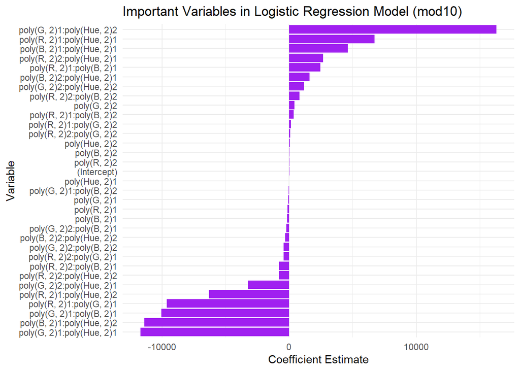

```r
important_vars_mod10_df <- as.data.frame(important_vars_mod10)
important_vars_mod10_df$Variable <- rownames(important_vars_mod10_df)

ggplot(important_vars_mod10_df, aes(x = reorder(Variable, Estimate), y = Estimate)) +
  geom_bar(stat = "identity", fill = "purple") +
  coord_flip() +
  theme_minimal() +
  labs(title = "Important Variables in Logistic Regression Model (mod10)",
       x = "Variable",
       y = "Coefficient Estimate")
```

**Most important variables similar for the regression and classification tasks**

```r
color_model_inputs <- c("R", "G", "B", "Hue", "Saturation", "Lightness")


important_vars_lm9_df <- as.data.frame(important_vars_lm9)
important_vars_lm9_df$Variable <- rownames(important_vars_lm9_df)


dominant_input_names_lm9 <- unique(grep(paste(color_model_inputs, collapse = "|"), important_vars_lm9_df$Variable, value = TRUE))
dominant_input_names_mod10 <- unique(grep(paste(color_model_inputs, collapse = "|"), important_vars_mod10_df$Variable, value = TRUE))

cat("Dominant color model inputs in linear regression model (fit_lm9):\n")
```

```
## Dominant color model inputs in linear regression model (fit_lm9):
```

```r
print(dominant_input_names_lm9)
```

```
##   [1] "poly(G, 2)1:Lightnesspale"      "poly(G, 2)1:Lightnesslight"
##   [3] "poly(G, 2)2:Lightnesspale"      "poly(G, 2)1"
##   [5] "poly(R, 2)1:Lightnesspale"      "poly(G, 2)2:Lightnesslight"
##   [7] "poly(R, 2)2:Lightnesspale"      "poly(G, 2)1:Lightnesssoft"
##   [9] "poly(G, 2)2:Lightnesssoft"      "poly(R, 2)1"
##  [11] "poly(G, 2)2:Lightnessmidtone"   "poly(R, 2)1:Lightnesssoft"
##  [13] "poly(B, 2)2:Lightnesspale"      "poly(B, 2)2:Lightnesslight"
##  [15] "poly(G, 2)1:Saturationgray"     "poly(B, 2)2:Lightnesssoft"
##  [17] "poly(G, 2)1:Lightnessmidtone"   "poly(R, 2)1:Saturationgray"
##  [19] "poly(G, 2)2:Lightnesssaturated" "poly(B, 2)1:Lightnesssaturated"
##  [21] "poly(B, 2)2:Lightnessmidtone"   "poly(R, 2)2:Lightnesssoft"
##  [23] "poly(R, 2)1:Lightnessmidtone"   "poly(B, 2)2:Lightnesssaturated"
##  [25] "poly(R, 2)1:Saturationneutral"  "poly(G, 2)1:Saturationshaded"
##  [27] "poly(G, 2)2:Saturationgray"     "poly(B, 2)1:Lightnessdeep"
##  [29] "Lightnesspale"                  "poly(B, 2)1:Lightnessmidtone"
```

[output cut: 37 more lines]

```r
cat("\nDominant color model inputs in logistic regression model (mod10):\n")
```

```
##
## Dominant color model inputs in logistic regression model (mod10):
```

```r
print(dominant_input_names_mod10)
```

```
##  [1] "poly(G, 2)1:poly(Hue, 2)2" "poly(G, 2)1:poly(Hue, 2)1"
##  [3] "poly(B, 2)1:poly(Hue, 2)2" "poly(G, 2)1:poly(B, 2)1"
##  [5] "poly(R, 2)1:poly(G, 2)1"   "poly(R, 2)1:poly(Hue, 2)1"
##  [7] "poly(R, 2)1:poly(Hue, 2)2" "poly(B, 2)1:poly(Hue, 2)1"
##  [9] "poly(G, 2)2:poly(Hue, 2)1" "poly(R, 2)2:poly(Hue, 2)1"
## [11] "poly(R, 2)1:poly(B, 2)1"   "poly(B, 2)2:poly(Hue, 2)1"
## [13] "poly(G, 2)2:poly(Hue, 2)2" "poly(R, 2)2:poly(Hue, 2)2"
## [15] "poly(R, 2)2:poly(B, 2)2"   "poly(R, 2)2:poly(B, 2)1"
## [17] "poly(R, 2)2:poly(G, 2)1"   "poly(G, 2)2:poly(B, 2)2"
## [19] "poly(G, 2)2"               "poly(R, 2)1:poly(B, 2)2"
## [21] "poly(B, 2)2:poly(Hue, 2)2" "poly(G, 2)2:poly(B, 2)1"
## [23] "poly(B, 2)1"               "poly(R, 2)1:poly(G, 2)2"
## [25] "poly(R, 2)1"               "poly(R, 2)2:poly(G, 2)2"
## [27] "poly(G, 2)1"               "poly(Hue, 2)2"
## [29] "poly(G, 2)1:poly(B, 2)2"   "poly(B, 2)2"
## [31] "poly(R, 2)2"               "poly(Hue, 2)1"
```

```r
non_helpful_input_names_lm9 <- setdiff(color_model_inputs, unique(grep(paste(color_model_inputs, collapse = "|"), rownames(important_vars_lm9_df), value = TRUE)))
non_helpful_input_names_mod10 <- setdiff(color_model_inputs, unique(grep(paste(color_model_inputs, collapse = "|"), rownames(important_vars_mod10_df), value = TRUE)))

cat("\nNon-helpful color model inputs in linear regression model (fit_lm9):\n")
```

```
##
## Non-helpful color model inputs in linear regression model (fit_lm9):
```

```r
print(non_helpful_input_names_lm9)
```

```
## [1] "R"          "G"          "B"          "Saturation" "Lightness"
```

```r
cat("\nNon-helpful color model inputs in logistic regression model (mod10):\n")
```

```
##
## Non-helpful color model inputs in logistic regression model (mod10):
```

```r
print(non_helpful_input_names_mod10)
```

```
## [1] "R"          "G"          "B"          "Hue"        "Saturation"
## [6] "Lightness"
```

## Part iv: Interpretation – ivB) Input insights

```r
df_holdout$predicted_outcome_mod10 <- predict(mod10, newdata = df_holdout, type = "response")
head(df_holdout)
```

```
## # A tibble: 6 × 7
##       R     G     B Lightness Saturation   Hue predicted_outcome_mod10
##   <dbl> <dbl> <dbl> <chr>     <chr>      <dbl>                   <dbl>
## 1   225   218   202 light     gray          13                   0.814
## 2   237   235   231 pale      gray          34                   0.207
## 3   201   187   163 midtone   neutral       13                   0.853
## 4   178   172   162 soft      gray          11                   0.974
## 5   207   197   182 light     gray           7                   0.966
## 6   201   191   178 soft      gray          12                   0.933
```

```r
library(dplyr)


df_holdout <- df_holdout %>%
  mutate(prediction_category = case_when(
    predicted_outcome_mod10 > 0.66  ~ "High",
    predicted_outcome_mod10 > 0.33  ~ "Medium",
    TRUE                             ~ "Low"
  ))


prediction_distribution <- df_holdout %>%
  group_by(Lightness, Saturation) %>%
  count(prediction_category) %>%
  ungroup() %>%
  arrange(Lightness, Saturation, prediction_category)


print(prediction_distribution)
```

```
## # A tibble: 119 × 4
##    Lightness Saturation prediction_category     n
##    <chr>     <chr>      <chr>               <int>
##  1 dark      bright     Low                    16
##  2 dark      bright     Medium                  2
##  3 dark      gray       High                    3
##  4 dark      gray       Low                     5
##  5 dark      gray       Medium                  2
##  6 dark      muted      Low                    17
##  7 dark      muted      Medium                  1
##  8 dark      neutral    High                    7
##  9 dark      neutral    Low                     8
## 10 dark      neutral    Medium                  2
## # ℹ 109 more rows
```

**Easiest to predict in the classification tasks**

```r
df_holdout <- df_holdout %>%
  mutate(prediction_confidence = abs(predicted_outcome_mod10 - 0.5))


average_confidence <- df_holdout %>%
  group_by(Lightness, Saturation) %>%
  summarise(average_confidence = mean(prediction_confidence), .groups = "drop") %>%
  ungroup()


easiest_combination <- average_confidence[which.max(average_confidence$average_confidence), ]
easiest_combination
```

```
## # A tibble: 1 × 3
##   Lightness Saturation average_confidence
##   <chr>     <chr>                   <dbl>
## 1 deep      bright                  0.481
```

**Hardest to predict classification tasks**

```r
df_holdout <- df_holdout %>%
  mutate(prediction_confidence = abs(predicted_outcome_mod10 - 0.5))


average_confidence <- df_holdout %>%
  group_by(Lightness, Saturation) %>%
  summarise(average_confidence = mean(prediction_confidence), .groups = "drop") %>%
  ungroup()


hardest_combination <- average_confidence[which.min(average_confidence$average_confidence), ]
hardest_combination
```

```
## # A tibble: 1 × 3
##   Lightness Saturation average_confidence
##   <chr>     <chr>                   <dbl>
## 1 light     gray                    0.232
```

**Easiest to predict in the regression tasks**

```r
df_holdout$predicted_outcome_lm9 <- predict(fit_lm9, newdata = df_holdout)
head(df_holdout)
```

```
## # A tibble: 6 × 10
##       R     G     B Lightness Saturation   Hue predicted_outcome_mod10
##   <dbl> <dbl> <dbl> <chr>     <chr>      <dbl>                   <dbl>
## 1   225   218   202 light     gray          13                   0.814
## 2   237   235   231 pale      gray          34                   0.207
## 3   201   187   163 midtone   neutral       13                   0.853
## 4   178   172   162 soft      gray          11                   0.974
## 5   207   197   182 light     gray           7                   0.966
## 6   201   191   178 soft      gray          12                   0.933
## # ℹ 3 more variables: prediction_category <chr>, prediction_confidence <dbl>,
## #   predicted_outcome_lm9 <dbl>
```

```r
df_holdout <- df_holdout %>%
  mutate(prediction_category = case_when(
    predicted_outcome_lm9 > 0.66  ~ "High",
    predicted_outcome_lm9 > 0.33  ~ "Medium",
    TRUE                             ~ "Low"
  ))

prediction_distribution <- df_holdout %>%
  group_by(Lightness, Saturation) %>%
  count(prediction_category) %>%
  ungroup() %>%
  arrange(Lightness, Saturation, prediction_category)

print(prediction_distribution)
```

```
## # A tibble: 83 × 4
##    Lightness Saturation prediction_category     n
##    <chr>     <chr>      <chr>               <int>
##  1 dark      bright     Low                    18
##  2 dark      gray       Low                    10
##  3 dark      muted      Low                    18
##  4 dark      neutral    Low                    17
##  5 dark      pure       Low                    16
##  6 dark      pure       Medium                  2
##  7 dark      shaded     Low                    18
##  8 dark      subdued    Low                    18
##  9 deep      bright     Low                    18
## 10 deep      gray       Low                    13
## # ℹ 73 more rows
```

```r
df_holdout <- df_holdout %>%
  mutate(regression_confidence = abs(predicted_outcome_lm9))

average_confidence <- df_holdout %>%
  group_by(Lightness, Saturation) %>%
  summarise(
    average_regression_confidence = mean(regression_confidence),
    .groups = "drop"
  ) %>%
  ungroup()


easiest_regression_combination <- average_confidence[which.max(average_confidence$average_regression_confidence), ]
easiest_regression_combination
```

```
## # A tibble: 1 × 3
##   Lightness Saturation average_regression_confidence
##   <chr>     <chr>                              <dbl>
## 1 dark      gray                                2.31
```

```r
df_holdout <- df_holdout %>%
  mutate(regression_confidence = abs(predicted_outcome_lm9))

average_confidence <- df_holdout %>%
  group_by(Lightness, Saturation) %>%
  summarise(
    average_regression_confidence = mean(regression_confidence),
    .groups = "drop"
  ) %>%
  ungroup()

hardest_regression_combination <- average_confidence[which.min(average_confidence$average_regression_confidence), ]

hardest_regression_combination
```

```
## # A tibble: 1 × 3
##   Lightness Saturation average_regression_confidence
##   <chr>     <chr>                              <dbl>
## 1 soft      gray                               0.165
```

## Part iv: Interpretation – ivC) Prediction insights

**Regression hardest and easiest trend with two important inputs**

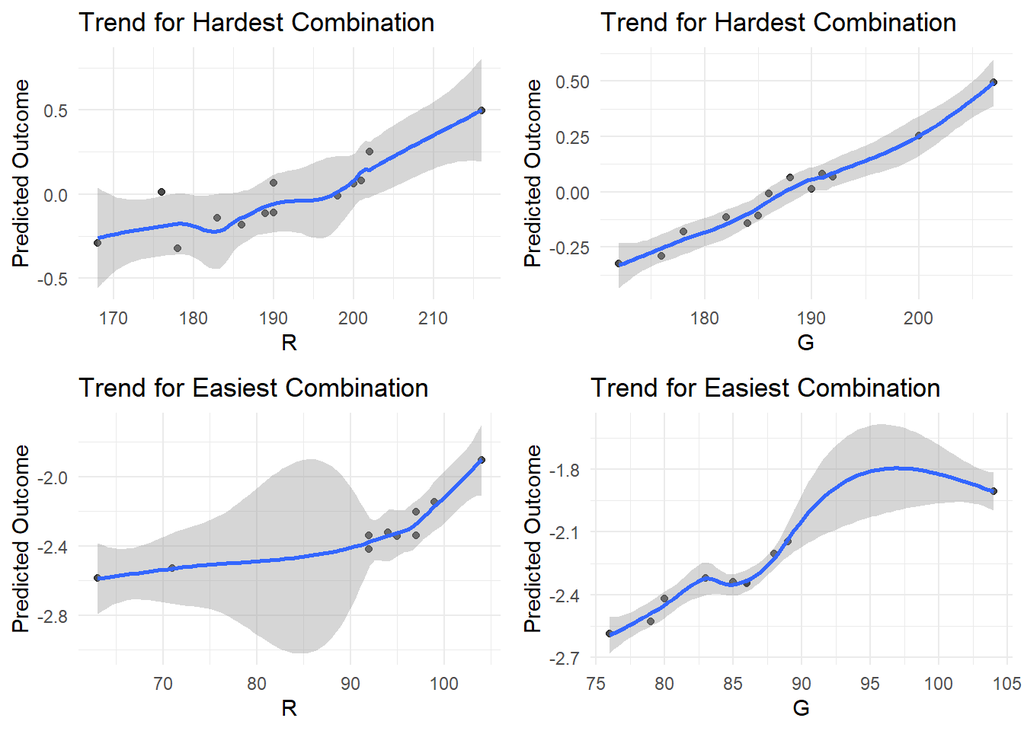

```r
library(ggplot2)
library(dplyr)


important_inputs <- c("R", "G")

hardest_data <- df_holdout %>%
  filter(Lightness == hardest_regression_combination$Lightness,
         Saturation == hardest_regression_combination$Saturation)

easiest_data <- df_holdout %>%
  filter(Lightness == easiest_regression_combination$Lightness,
         Saturation == easiest_regression_combination$Saturation)


create_trend_plot <- function(data, input_name, title_suffix) {
  ggplot(data, aes_string(x = input_name, y = "predicted_outcome_lm9")) +
    geom_point(alpha = 0.7) +
    geom_smooth(method = "loess",formula = y ~ x) +
    labs(title = paste("Trend for", title_suffix, "Combination"),
         x = input_name,
         y = "Predicted Outcome") +
    theme_minimal()
}

plots_hardest <- lapply(important_inputs, function(input) {
  create_trend_plot(hardest_data, input, "Hardest")
})
plots_easiest <- lapply(important_inputs, function(input) {
  create_trend_plot(easiest_data, input, "Easiest")
})


library(gridExtra)
grid.arrange(grobs = c(plots_hardest, plots_easiest), ncol = 2)
```

**Classification hardest and easiest trend with two important inputs**

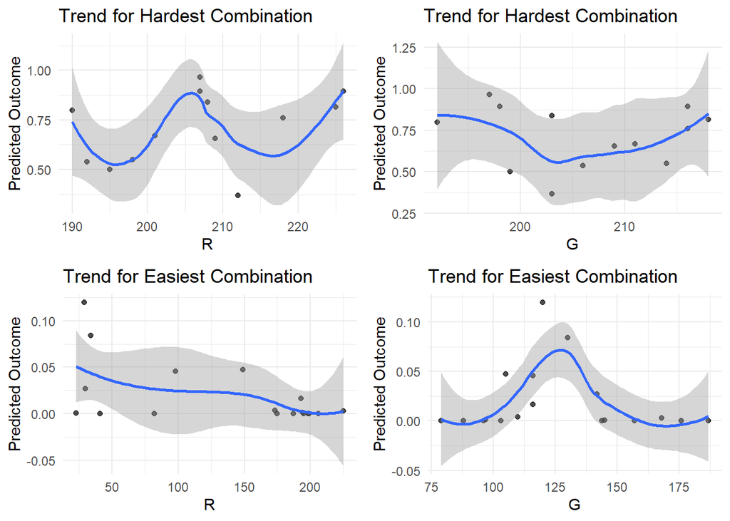

```r
library(ggplot2)
library(dplyr)


important_inputs <- c("R", "G")

hardest_data <- df_holdout %>%
  filter(Lightness == hardest_combination$Lightness,
         Saturation == hardest_combination$Saturation)

easiest_data <- df_holdout %>%
  filter(Lightness == easiest_combination$Lightness,
         Saturation == easiest_combination$Saturation)


create_trend_plot <- function(data, input_name, title_suffix) {
  ggplot(data, aes_string(x = input_name, y = "predicted_outcome_mod10")) +
    geom_point(alpha = 0.7) +
    geom_smooth(method = "loess",  formula = y ~ x) +
    labs(title = paste("Trend for", title_suffix, "Combination"),
         x = input_name,
         y = "Predicted Outcome") +
    theme_minimal()
}

plots_hardest <- lapply(important_inputs, function(input) {
  create_trend_plot(hardest_data, input, "Hardest")
})


plots_easiest <- lapply(important_inputs, function(input) {
  create_trend_plot(easiest_data, input, "Easiest")
})


library(gridExtra)
grid.arrange(grobs = c(plots_hardest, plots_easiest), ncol = 2)
```

**Visualize your predictive trends as a surface plot - Regression**

```r
Model9 <- lm(logit_response ~ (poly(R, 2) + poly(G, 2) + poly(B, 2) + Hue) * (Lightness + Saturation), data = df_train)

unique_lightness <- unique(df_train$Lightness,2)
unique_saturation <- unique(df_train$Saturation,2)

viz_grid <- expand.grid(
  R = seq(min(df_train$R), max(df_train$R), length.out = 101),
  G = seq(min(df_train$G), max(df_train$G), length.out = 101),
  B = seq(min(df_train$B), max(df_train$B), length.out = 2),
  Hue = seq(min(df_train$Hue), max(df_train$Hue), length.out = 2),
  Lightness = unique_lightness,
  Saturation = unique_saturation
)

tidy_predict <- function(mod, xnew)
{
  pred_df <- predict(mod, xnew, interval = "confidence") %>%
    as.data.frame() %>% tibble::as_tibble() %>%
    dplyr::select(pred = fit, ci_lwr = lwr, ci_upr = upr) %>%
    bind_cols(predict(mod, xnew, interval = 'prediction') %>%
                as.data.frame() %>% tibble::as_tibble() %>%
                dplyr::select(pred_lwr = lwr, pred_upr = upr))

  xnew %>% bind_cols(pred_df)
}

pred_Model9 <- tidy_predict(Model9, viz_grid)
```

```r
library(viridis)
```

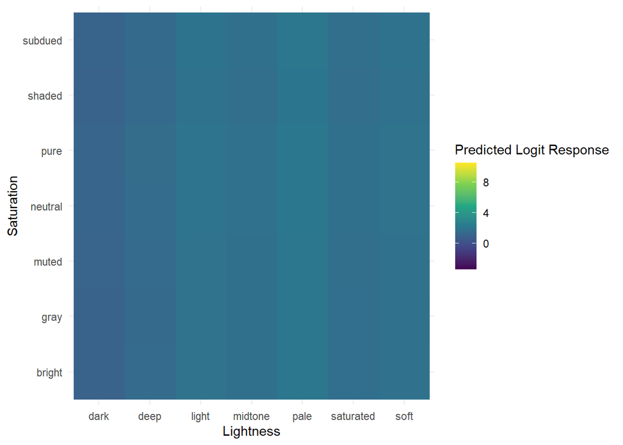

```r
ggplot(pred_Model9, aes(x = Lightness, y = Saturation, fill = pred)) +
  geom_raster() +
  scale_fill_viridis_c(option = "viridis", limits = range(pred_Model9$pred, na.rm = TRUE)) +
  labs(x = "Lightness", y = "Saturation", fill = "Predicted Logit Response") +
  theme_minimal()
```

**Visualize your predictive trends as a surface plot - Classification**

```r
viz_grid <- expand.grid(R = seq(min(df_train$R), max(df_train$R), length.out = 101),
                        G = seq(min(df_train$G), max(df_train$G), length.out = 101),
                        B = unique(df_train$B),
                        Lightness = unique(df_train$Lightness),
                        KEEP.OUT.ATTRS = FALSE,
                        stringsAsFactors = FALSE) %>%
  as.data.frame() %>% tibble::as_tibble()

viz_grid %>% glimpse()
```

```
## Rows: 13,067,481
## Columns: 4
## $ R         <dbl> 0.00, 2.55, 5.10, 7.65, 10.20, 12.75, 15.30, 17.85, 20.40, 2…
## $ G         <dbl> 58, 58, 58, 58, 58, 58, 58, 58, 58, 58, 58, 58, 58, 58, 58, …
## $ B         <dbl> 62, 62, 62, 62, 62, 62, 62, 62, 62, 62, 62, 62, 62, 62, 62, …
## $ Lightness <chr> "dark", "dark", "dark", "dark", "dark", "dark", "dark", "dar…
```

```r
generate_glm_post_samples <- function(mvn_result, num_samples)
{
  # specify the number of unknown beta parameters
  length_beta <- length(mvn_result$mode)

  # generate the random samples
  beta_samples <- MASS::mvrnorm(n = num_samples,
                                mu = mvn_result$mode,
                                Sigma = mvn_result$var_matrix)

  # change the data type and name
  beta_samples %>%
    as.data.frame() %>% tibble::as_tibble() %>%
    purrr::set_names(sprintf("beta_%02d", (1:length_beta) - 1))
}

post_logistic_pred_samples <- function(Xnew, Bmat)
{
  # calculate the linear predictor at all prediction points and posterior samples
  eta_mat <- Xnew %*% t(Bmat)

  # calculate the event probability
  mu_mat <- boot::inv.logit(eta_mat)

  # book keeping
  list(eta_mat = eta_mat, mu_mat = mu_mat)
}

summarize_logistic_pred_from_laplace <- function(mvn_result, Xtest, num_samples)
{
  # generate posterior samples of the beta parameters
  betas <- generate_glm_post_samples(mvn_result, num_samples)

  # data type conversion
  betas <- as.matrix(betas)

  # make posterior predictions on the test set
  pred_test <- post_logistic_pred_samples(Xtest, betas)

  # calculate summary statistics on the posterior predicted probability
  # summarize over the posterior samples

  # posterior mean, should you summarize along rows (rowMeans) or
  # summarize down columns (colMeans) ???
  mu_avg <- rowMeans(pred_test$mu_mat)

  # posterior quantiles
  mu_q05 <- apply(pred_test$mu_mat, 1, stats::quantile, probs = 0.05)
  mu_q95 <- apply(pred_test$mu_mat, 1, stats::quantile, probs = 0.95)

  # book keeping
  tibble::tibble(
    mu_avg = mu_avg,
    mu_q05 = mu_q05,
    mu_q95 = mu_q95
  ) %>%
    tibble::rowid_to_column("pred_id")
}

my_laplace <- function(start_guess, logpost_func, ...)
{
  # code adapted from the `LearnBayes`` function `laplace()`
  fit <- optim(start_guess,
               logpost_func,
               gr = NULL,
               ...,
               method = "BFGS",
               hessian = TRUE,
               control = list(fnscale = -1, maxit = 5001))

  mode <- fit$par
  post_var_matrix <- -solve(fit$hessian)
  p <- length(mode)
  int <- p/2 * log(2 * pi) + 0.5 * log(det(post_var_matrix)) + logpost_func(mode, ...)
  # package all of the results into a list
  list(mode = mode,
       var_matrix = post_var_matrix,
       log_evidence = int,
       converge = ifelse(fit$convergence == 0,
                         "YES",
                         "NO"),
       iter_counts = as.numeric(fit$counts[1]))
}

logistic_logpost <- function(unknowns, my_info)
{
  # extract the design matrix and assign to X
  X <- my_info$design_matrix

  # calculate the linear predictor
  eta <- as.vector( X %*% as.matrix(unknowns))

  # calculate the event probability
  mu <- boot::inv.logit(eta)

  # evaluate the log-likelihood
  log_lik <- sum(dbinom(x = my_info$yobs,
                        size = 1,
                        prob = mu,
                        log = TRUE))

  # evaluate the log-prior
  log_prior <- sum(dnorm(x = unknowns,
                         mean = my_info$mu_beta,
                         sd = my_info$tau_beta,
                         log = TRUE))

  # sum together
  log_lik + log_prior
}



mod10 <-  glm(outcome ~ poly(R, 2) * poly(G, 2) + poly(R, 2) * poly(B, 2) + poly(R, 2) * poly(Hue, 2) + poly(G, 2) * poly(B, 2) + poly(G, 2) * poly(Hue, 2) + poly(B, 2) * poly(Hue, 2), family = binomial, data = df_train)
mod10
```

```
##
## Call:  glm(formula = outcome ~ poly(R, 2) * poly(G, 2) + poly(R, 2) *
##     poly(B, 2) + poly(R, 2) * poly(Hue, 2) + poly(G, 2) * poly(B,
##     2) + poly(G, 2) * poly(Hue, 2) + poly(B, 2) * poly(Hue, 2),
##     family = binomial, data = df_train)
##
## Coefficients:
##               (Intercept)                poly(R, 2)1
##                    21.976                   -112.461
##               poly(R, 2)2                poly(G, 2)1
##                    22.798                    -76.129
##               poly(G, 2)2                poly(B, 2)1
##                   411.687                   -142.532
##               poly(B, 2)2              poly(Hue, 2)1
##                    39.061                      7.546
##             poly(Hue, 2)2    poly(R, 2)1:poly(G, 2)1
##                    49.186                  -9629.478
##   poly(R, 2)2:poly(G, 2)1    poly(R, 2)1:poly(G, 2)2
##                  -442.943                    135.122
##   poly(R, 2)2:poly(G, 2)2    poly(R, 2)1:poly(B, 2)1
##                    93.354                   2459.909
##   poly(R, 2)2:poly(B, 2)1    poly(R, 2)1:poly(B, 2)2
##                  -791.136                    350.000
##   poly(R, 2)2:poly(B, 2)2  poly(R, 2)1:poly(Hue, 2)1
##                   802.132                   6715.203
## poly(R, 2)2:poly(Hue, 2)1  poly(R, 2)1:poly(Hue, 2)2
##                  2666.738                  -6297.629
## poly(R, 2)2:poly(Hue, 2)2    poly(G, 2)1:poly(B, 2)1
##                  -804.060                 -10058.897
##   poly(G, 2)2:poly(B, 2)1    poly(G, 2)1:poly(B, 2)2
##                  -227.392                    -45.627
##   poly(G, 2)2:poly(B, 2)2  poly(G, 2)1:poly(Hue, 2)1
##                  -440.288                 -11709.539
## poly(G, 2)2:poly(Hue, 2)1  poly(G, 2)1:poly(Hue, 2)2
##                 -3240.728                  16311.142
## poly(G, 2)2:poly(Hue, 2)2  poly(B, 2)1:poly(Hue, 2)1
##                  1177.194                   4630.249
## poly(B, 2)2:poly(Hue, 2)1  poly(B, 2)1:poly(Hue, 2)2
##                  1615.417                 -11406.089
## poly(B, 2)2:poly(Hue, 2)2
##                  -299.380
##
## Degrees of Freedom: 834 Total (i.e. Null);  802 Residual
## Null Deviance:       898
## Residual Deviance: 500.2     AIC: 566.2
```

```r
Xmat_10 <- model.matrix( mod10$formula, data = df_train)

info_10 <- list(
  yobs = df_train$outcome,
  design_matrix = Xmat_10,
  mu_beta = 0,
  tau_beta = 4.5
)

laplace_10 <- my_laplace(rep(0, ncol(Xmat_10)), logistic_logpost, info_10)

Xviz_10 <- model.matrix( mod10$formula, data = df_train)


post_pred_summary_10 <- summarize_logistic_pred_from_laplace(laplace_10, Xviz_10, 2500)
```

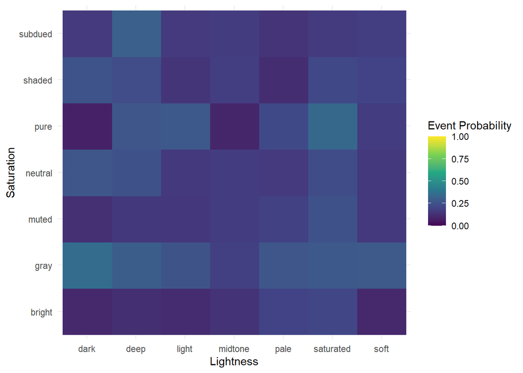

```r
post_pred_summary_10 <- post_pred_summary_10 %>%
  mutate(pred_id = row_number()) %>%
  left_join(df_train %>% select(Lightness, Saturation) %>% mutate(pred_id = row_number()), by = "pred_id") %>%
  select(-pred_id)
ggplot(post_pred_summary_10, aes(x = Lightness, y = Saturation, fill = mu_avg)) +
  geom_raster() +
  scale_fill_viridis_c(option = "viridis", limits = c(0, 1)) +
  labs(x = "Lightness", y = "Saturation", fill = "Event Probability") +
  theme_minimal()
```

**Surface plot for the hardest to predict Lightness and Saturation combinations and again for the easiest to predict Lightness and Saturation combinations - Regression**

```r
reference_values <- df_holdout %>%
  summarise(across(c(R, G, B, Hue), median, na.rm = TRUE))
```

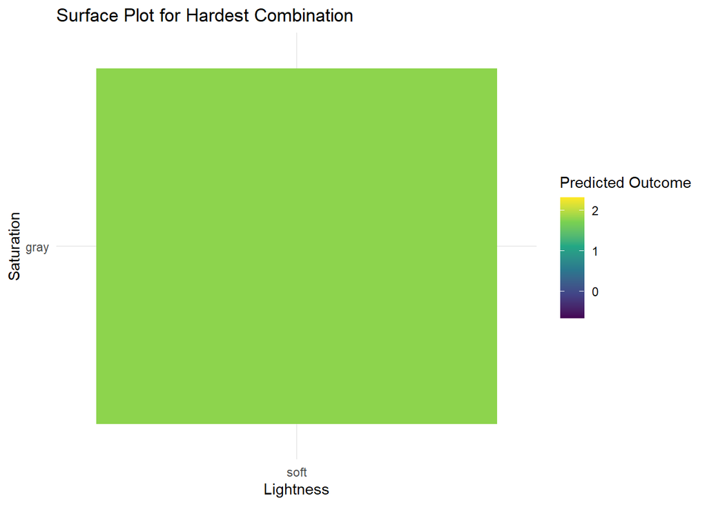

```r
prediction_grid <- expand.grid(R = seq(min(df_holdout$R), max(df_holdout$R), length.out = 101),
                        G = seq(min(df_holdout$G), max(df_holdout$G), length.out = 101),
                        B = unique(df_holdout$B),
                        Lightness = unique(df_holdout$Lightness),
                        KEEP.OUT.ATTRS = FALSE,
                        stringsAsFactors = FALSE) %>%
  as.data.frame() %>% tibble::as_tibble()


create_surface_plot <- function(data_subset, title_suffix) {
  ggplot(data_subset, aes(x = Lightness, y = Saturation, fill = pred)) +
    geom_raster(interpolate = TRUE) +
    scale_fill_viridis_c() +
    labs(title = paste("Surface Plot for", title_suffix, "Combination"),
         x = "Lightness", y = "Saturation", fill = "Predicted Outcome") +
    theme_minimal()
}


hardest_subset <- pred_Model9 %>%
  filter(Lightness == hardest_regression_combination$Lightness,
         Saturation == hardest_regression_combination$Saturation)

easiest_subset <- pred_Model9 %>%
  filter(Lightness == easiest_regression_combination$Lightness,
         Saturation == easiest_regression_combination$Saturation)


hardest_surface_plot <- create_surface_plot(hardest_subset, "Hardest")
easiest_surface_plot <- create_surface_plot(easiest_subset, "Easiest")

print(hardest_surface_plot)
```

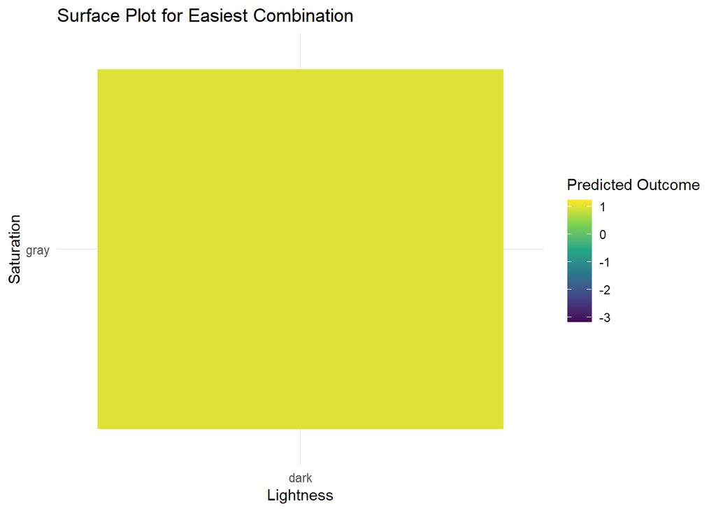

```r
print(easiest_surface_plot)
```

**Surface plot for the hardest to predict Lightness and Saturation combinations and again for the easiest to predict Lightness and Saturation combinations - Classification**

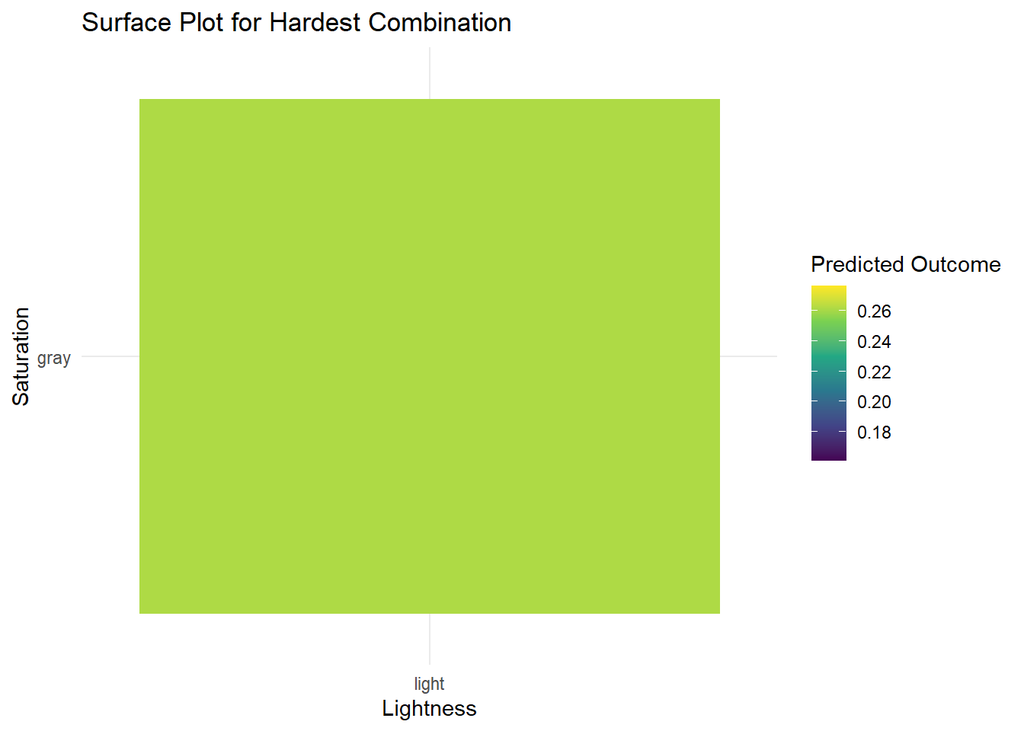

```r
reference_values <- df_holdout %>%
  summarise(across(c(R, G, B, Hue), median, na.rm = TRUE))

prediction_grid <- expand.grid(R = seq(min(df_holdout$R), max(df_holdout$R), length.out = 101),
                        G = seq(min(df_holdout$G), max(df_holdout$G), length.out = 101),
                        B = unique(df_holdout$B),
                        Lightness = unique(df_holdout$Lightness),
                        KEEP.OUT.ATTRS = FALSE,
                        stringsAsFactors = FALSE) %>%
  as.data.frame() %>% tibble::as_tibble()


create_surface_plot <- function(data_subset, title_suffix) {
  ggplot(data_subset, aes(x = Lightness, y = Saturation, fill = mu_avg)) +
    geom_raster(interpolate = TRUE) +
    scale_fill_viridis_c() +
    labs(title = paste("Surface Plot for", title_suffix, "Combination"),
         x = "Lightness", y = "Saturation", fill = "Predicted Outcome") +
    theme_minimal()
}


hardest_subset <- post_pred_summary_10 %>%
  filter(Lightness == hardest_combination$Lightness,
         Saturation == hardest_combination$Saturation)

easiest_subset <- post_pred_summary_10 %>%
  filter(Lightness == easiest_combination$Lightness,
         Saturation == easiest_combination$Saturation)


hardest_surface_plot <- create_surface_plot(hardest_subset, "Hardest")
easiest_surface_plot <- create_surface_plot(easiest_subset, "Easiest")

print(hardest_surface_plot)
```

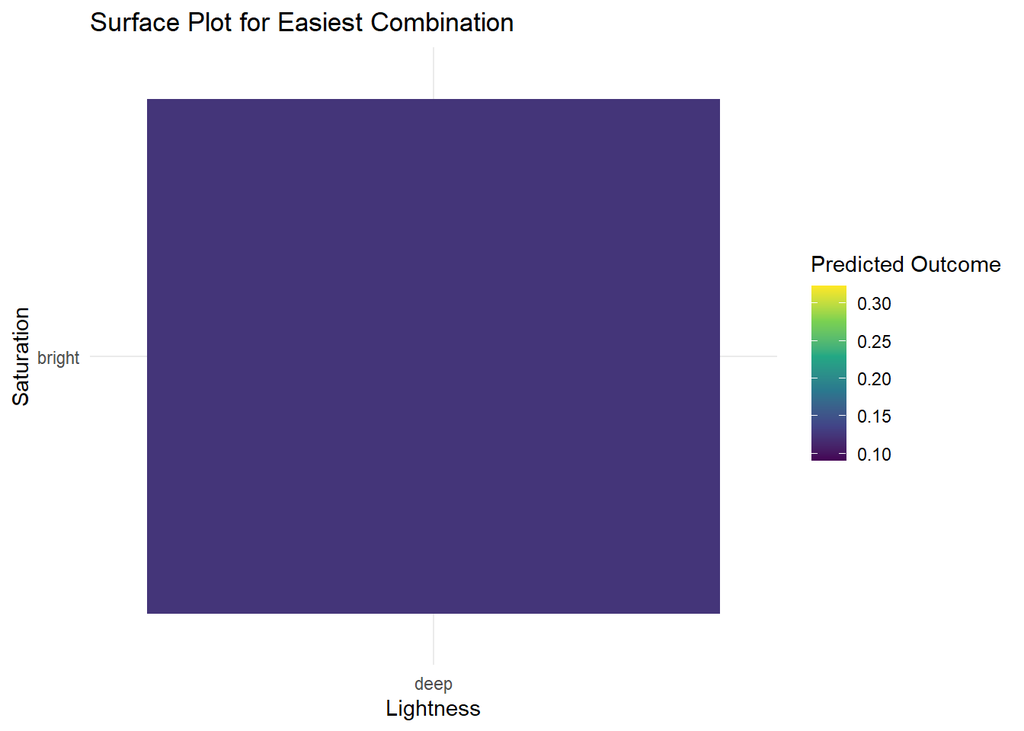

```r
print(easiest_surface_plot)
```

## Part iv: Interpretation – ivC) Prediction insights

From these plots, we can conclude that the classification model differentiates more between the combinations of saturation and lightness in terms of event probability, while the regression model yields a more consistent prediction across these inputs. The uniformity in the regression plot could also indicate that other variables, not depicted here, might have a more significant impact on the model’s predictions.

**Classification - Easiest and Hardest Combination**

The surface plots for the hardest and easiest combinations reveal a striking uniformity in color, indicating a lack of variation in predicted outcomes across different levels of Lightness and Saturation. This uniformity suggests that the model fails to capture any significant interaction or relationship between these inputs and the predicted outcome within the plotted ranges. Despite this overall similarity, there are notable differences between the two plots. The scale of the predicted outcome differs, with the hardest combination plot ranging from approximately 0.175 to 0.275, while the easiest combination plot ranges from approximately 0.10 to 0.30. Additionally, the color coding differs, possibly due to the different ranges of predicted outcomes in each plot, with the hardest combination shown in shades of green and the easiest combination in shades of purple. The lack of gradient in both plots implies that the model may not be sensitive to changes in Lightness and Saturation within these ranges, suggesting either a lack of influence of these inputs on the model’s predictions or a potential performance issue for these particular combinations.